# Practical Sheet 3 Solutions

```
set.seed(1)
```

### Question 1

Using the method of moments we have the estimator
$$\hat{\mu}=\bar{X}$$
A 95% confidence interval is then
$$(\bar{X}-1.96\frac{\sigma}{\sqrt{n}},\bar{X}+1.96\frac{\sigma}{\sqrt{n}})$$
We are given that $\sigma=1$ so it remains to calculate the mean, $\bar{x}$.

```
data1=c(15.9,14.5,12.7,13.8,14.2)
xbar=mean(data1)
xbar-1.96/sqrt(5)
```

```
[1] 13.34346
```

```
xbar+1.96/sqrt(5)
```

```
[1] 15.09654
```

So we have the $95\%$ confidence interval
$$(13.34,15.10)$$

Now we simulate more data with $\mu=15$:

```
x1 = rnorm(200, 15, 1)
x2 = rnorm(200, 15, 1)
x3 = rnorm(200, 15, 1)
x4 = rnorm(200, 15, 1)
x5 = rnorm(200, 15, 1)
m1 = cbind(x1, x2, x3, x4, x5)
```

We can view two samples of the data

```
m1[1,]
```

```
      x1       x2       x3       x4       x5
14.37355 15.40940 16.07444 14.65893 13.91309
```

```
m1[2,]
```

```
      x1       x2       x3       x4       x5
15.18364 16.68887 16.89565 16.50242 13.17392
```

Calculate the mean:

```
sample.mean = apply(m1, 1, mean)
```

The confidence interval bounds

```
ci.lower = sample.mean - 1.96/sqrt(5)
ci.upper = sample.mean + 1.96/sqrt(5)
data.frame(ci.lower, ci.upper)
```

| ci.lower | ci.upper |
| --- | --- |
| 14.00934 | 15.76242 |
| 14.81236 | 16.56544 |
| 14.45777 | 16.21085 |
| 14.40423 | 16.15731 |
| 13.50181 | 15.25489 |
| 14.12083 | 15.87391 |
| 13.89651 | 15.64959 |
| 14.47491 | 16.22799 |
| 15.07018 | 16.82326 |
| 13.72391 | 15.47699 |

[output cut: 190 more lines]

We can count the numbers that do not contain $\mu$ by first ordering the CIs based on their lower interval

```
dd = data.frame(ci.lower, ci.upper)
dd[with(dd, order(ci.lower)), ]
```

|  | ci.lower | ci.upper |
| --- | --- | --- |
| 14 | 12.48744 | 14.24052 |
| 46 | 12.69317 | 14.44625 |
| 54 | 12.77675 | 14.52982 |
| 67 | 13.25788 | 15.01095 |
| 161 | 13.28567 | 15.03875 |
| 18 | 13.31101 | 15.06409 |
| 134 | 13.32510 | 15.07818 |
| 145 | 13.33078 | 15.08386 |
| 141 | 13.34747 | 15.10054 |
| 175 | 13.38088 | 15.13396 |

[output cut: 190 more lines]

```
count <- sum(dd$ci.lower <= 15 & dd$ci.upper >= 15)
200-count
```

```
[1] 12
```

If we look through we find there are $12$ which do not contain $\mu=15$. For a 95% CI we would only expect 5% of 200 (i.e. 10) not to contain the sample mean. Bear in mind this is a simulation which will give different results every time.

### Question 2

Remember you can add the data to your environment by using the command

scan()

```
data_mobile=c(45.8, 41.1, 55.9, 46.6, 57, 45, 58.5, 46.7, 49.3, 52.7, 54.9,
48.5, 40.4, 44.4, 51, 44.2, 59.1, 46.9, 50.7, 43.7, 41.7, 52.8,
60.5, 38.5, 60.4, 53.8, 47.3, 50.2, 58.8, 50.7)

data_tv= c(23.1, 15.9, 21, 26, 25.1, 14.7, 24.2, 16.6, 18.2, 16.5, 20.7,
15.3, 17.7, 19.1, 22.7, 21.9, 14.6, 26.3, 25.8, 9.4, 17, 21.2,
17.9, 24.7, 21.1, 17.2, 19.1, 22.7, 24, 24.7, 22.5, 8.3, 2.5,
30.4)

data_travel=c(3.7, 14.3, 11, 26.5, 5.2, 4.8, 24.2, 16.9, 8.2, 26.5, 40.7,
5.3)
```

For (a), this can be considered as a large sample so we use the approximation to the normal distribution and s rather than σ

```
mean(data_mobile) + c(1,-1) * qnorm(0.025) * sd(data_mobile)/sqrt(30)
```

```
[1] 47.64801 52.15866
```

```
mean(data_mobile) + c(1,-1) * qnorm(0.005) * sd(data_mobile)/sqrt(30)
```

```
[1] 46.93933 52.86733
```

For (b), again, this can be considered as a large sample so we use the approximation to the normal distribution and s rather than σ

```
mean(data_tv) + c(1,-1) * qnorm(0.025) * sd(data_tv)/sqrt(34)
```

```
[1] 17.74298 21.55702
```

```
mean(data_tv) + c(1,-1) * qnorm(0.005) * sd(data_tv)/sqrt(34)
```

```
[1] 17.14375 22.15625
```

For (c), this is a small sample and we do not know the population variance so we use the t distribution. It has $11$ degrees of freedom.

```
mean(data_travel) + c(1,-1) * qt(0.025,11) * sd(data_travel)/sqrt(12)
```

```
[1]  8.205182 23.011485
```

```
mean(data_travel) + c(1,-1) * qt(0.005,11) * sd(data_travel)/sqrt(12)
```

```
[1]  5.161758 26.054908
```

The t distribution can only be used if the sample appears to come from a normal distribution. This may not be the case here as can be seen from the boxplot below.

```
boxplot(data_travel)
```

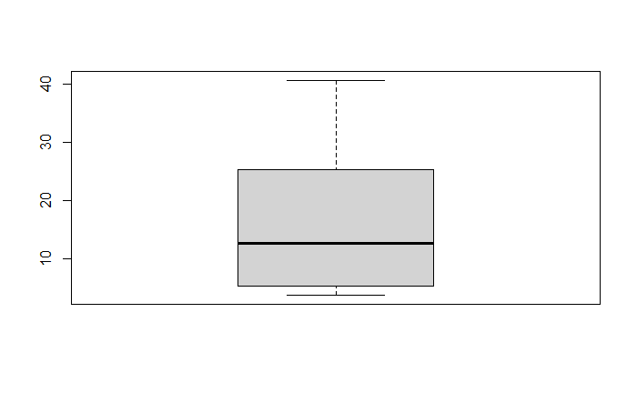

### Question 3

For the data set a 95% CI is calculated on R using the t.test command as

```
data3=c(12.4, 16.7, 20.5, 17, 10.6, 14.9, 16.8, 21.6, 17.7, 10.2, 15.1,
18.2, 19.3, 21, 15.8)
t.test(data3)
```

```
    One Sample t-test

data:  data3
t = 18.301, df = 14, p-value = 3.571e-11
alternative hypothesis: true mean is not equal to 0
95 percent confidence interval:
 14.58389 18.45611
sample estimates:
mean of x
    16.52
```

This gives a $95\%$ confidence interval as
$$(14.6, 18.5)$$

Now for a $99\%$ CI:

```
t.test(data3,conf.level = 0.99)
```

```
    One Sample t-test

data:  data3
t = 18.301, df = 14, p-value = 3.571e-11
alternative hypothesis: true mean is not equal to 0
99 percent confidence interval:
 13.83279 19.20721
sample estimates:
mean of x
    16.52
```

The $99\%$ CI is
$$(13.8,19.2)$$

```
boxplot(data3)
```

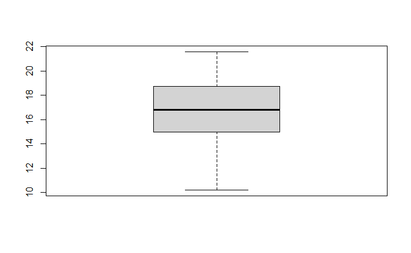

```
stem(data3)
```

```
  The decimal point is 1 digit(s) to the right of the |

  1 | 012
  1 | 556777889
  2 | 112
```

Both these look normally distributed so the t distribution seems appropriate.

```
mean(data3) +c(-1,1)* 1.96 * sd(data3)/sqrt(15)
```

```
[1] 14.7507 18.2893
```

This gives a slightly narrower CI than that in (a). However, as this is quite a small sample, the t distribution should be used if possible.

### Question 4

A laboratory experiment is performed to compare two methods of evaluating the coefficient of thermal expansion of a polymer. Samples of eighteen varying grades of a polymer are used, nine with method A and nine with method B, yielding the following results:

```
methodA=c(6.8,8.4,7.9,6.5,9.5,7.0,9.1,7.5,9.8)
methodB=c(7.2,8.3,8.3,7.5,9.5,7.7,9.4,7.8,10.3)
```

We can determine a $95\%$ confidence interval using

```
t.test(methodB,methodA,var.equal = TRUE)
```

```
    Two Sample t-test

data:  methodB and methodA
t = 0.7252, df = 16, p-value = 0.4788
alternative hypothesis: true difference in means is not equal to 0
95 percent confidence interval:
 -0.7479057  1.5256835
sample estimates:
mean of x mean of y
 8.444444  8.055556
```

### Question 5

An investigator was studying people’s ability to recognise faces when they are shown in black-and-white and in colour. She had 21 volunteers and split them into two groups: one group of 10 were shown the faces in black-and-white and the other group of 11 were shown them in colour. The variable measured was the average time (secs) taken to recognise the faces.

```
bw=c(1.7, 1.5, 1.6, 1.9, 1.2, 1.9, 1.6, 1.2, 1.2, 1)
col=c(1.3, 1.8, 1.6, 1.2, 1.7, 1.5, 1, 1.4, 1.5, 1, 1.1)
var.test(bw,col)
```

```
    F test to compare two variances

data:  bw and col
F = 1.3068, num df = 9, denom df = 10, p-value = 0.6796
alternative hypothesis: true ratio of variances is not equal to 1
95 percent confidence interval:
 0.3458132 5.1800391
sample estimates:
ratio of variances
          1.306815
```

So our CI is
$$(0.346, 5.180)$$

Using the same technique as in Q4, a 95% CI for the differences in population means is $(-0.16,0.38)$

```
t.test(bw,col,var.equal = TRUE)
```

```
    Two Sample t-test

data:  bw and col
t = 0.83116, df = 19, p-value = 0.4162
alternative hypothesis: true difference in means is not equal to 0
95 percent confidence interval:
 -0.1628612  0.3774067
sample estimates:
mean of x mean of y
 1.480000  1.372727
```

This is valid if the data come from normal populations and if the population variances are equal. Since, from (a), 1 lies in the interval (0.3458132, 5.1800391), there is not much evidence that the variances are different.

We now plot boxplots

```
boxplot(bw,col,names=c("b-w","col"))
```

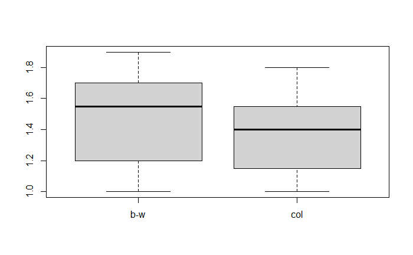

### Question 6

We have the data

```
data6=c(241, 251, 258, 246, 202, 246, 246, 301, 260, 228, 275, 266,
264, 250, 258, 265, 240, 227, 271, 306, 269, 252, 242, 274, 222,
244, 218, 228, 247, 202, 287, 279, 242, 262, 268, 226, 303, 214,
242, 233)
```

We obtain a $95\%$ confidence interval

```
t.test(data6)
```

```
    One Sample t-test

data:  data6
t = 63.3, df = 39, p-value < 2.2e-16
alternative hypothesis: true mean is not equal to 0
95 percent confidence interval:
 243.3426 259.4074
sample estimates:
mean of x
  251.375
```

The 95% CI does not contain the value 260 so it does not seem plausible that these data come from a population with mean 260. We can also check this using the method of hypothesis testing covered later. The P-value suggests we have evidence to reject the null hypothesis. (The code we will use later is t.test(x,mu=260))

```
t.test(data6,mu=260)
```

```
    One Sample t-test

data:  data6
t = -2.1719, df = 39, p-value = 0.03601
alternative hypothesis: true mean is not equal to 260
95 percent confidence interval:
 243.3426 259.4074
sample estimates:
mean of x
  251.375
```